# Credit Risk Modelling

### Credit Risk

Credit Risk defines as the risk of default on a debt that may arise from a borrower failing to make required payments. The credit that companies offer to their clients has associated with the risk that the clients may not pay their invoices. Thus, risk classification can play an essential factor in many companies, such as banks and insurance companies. Companies using customers information to classify the risk of the new customers based on some algorithm such as the k-nearest neighbor algorithm or decision tree. There are two types of Credit risks:

- **Good Risk**: An investment that one believes is likely to be profitable. The term most often refers to a loan made to a creditworthy person or company. Good risks are considered exceptionally likely to be repaid.
- **Bad Risk**: A loan that is unlikely to be repaid because of bad credit history, insufficient income, or some other reason. A bad risk increases the risk to the lender and the likelihood of default on the part of the borrower.

### Objective

- classifying the customers (based on their attributes) as either *good* or *bad* credit risk

#### About the dataset

- The real-world `risk` dataset. In the R package [`liver`](https://CRAN.R-project.org/package=liver).

This dataset has 6 variables in which the variable *risk* is the target variable along with 5 predictors, *mortgage*, *number of loans*, *age*, *marital status*, and *income*. In the target variable, customers are classified as either “*good risk*” or “*bad risk*”.

### classification algorithms:

- *CART* algorithm,
- *C5.0* algorithm,
- *Random Forest* algorithm,
- *kNN* algorithm.

### evaluating the accuracy of the predictions with:

- Confusion Matrix,
- MSE,
- ROC curve,
- AUC (Area Under the ROC curve).

### 1 Understading the dataset

```r
library(liver)
library(pROC)
data(risk)
str(risk)
```

```
## 'data.frame':    246 obs. of  6 variables:
##  $ age     : int  34 37 29 33 39 28 28 25 41 26 ...
##  $ marital : Factor w/ 3 levels "single","married",..: 3 3 3 3 3 3 3 3 3 3 ...
##  $ income  : num  28061 28009 27615 27287 26954 ...
##  $ mortgage: Factor w/ 2 levels "yes","no": 1 2 2 1 1 2 2 2 2 2 ...
##  $ nr.loans: int  3 2 2 2 2 2 3 2 2 2 ...
##  $ risk    : Factor w/ 2 levels "good risk","bad risk": 2 2 2 2 2 2 2 2 2 2 ...
```

```r
summary(risk)
```

```
##       age           marital        income      mortgage     nr.loans
##  Min.   :17.00   single :111   Min.   :15301   yes:175   Min.   :0.000
##  1st Qu.:32.00   married: 78   1st Qu.:26882   no : 71   1st Qu.:1.000
##  Median :41.00   other  : 57   Median :37662             Median :1.000
##  Mean   :40.64                 Mean   :38790             Mean   :1.309
##  3rd Qu.:50.00                 3rd Qu.:49398             3rd Qu.:2.000
##  Max.   :66.00                 Max.   :78399             Max.   :3.000
##         risk
##  good risk:123
##  bad risk :123
##
##
##
##
```

```r
find.na(risk)
```

```
## [1] " No missing values (NA) in the dataset."
```

There are 6 variables, with 246 observations. “Income” is a type of numeric variable, “age” and “nr.loans” are integers.” Marital”, “mortgage”, and “risk” are identified as a factor variable. There is no missing values identified.

```r
table(risk$age)
```

```
##
## 17 18 19 21 22 23 24 25 26 27 28 29 30 31 32 33 34 35 36 37 38 39 40 41 42 43
##  1  1  2  1  1  8  2  7  7  5  7  3  5  6  7  9  9  8  6  5 10  5  7  7  7  8
## 44 45 46 47 48 49 50 51 52 53 54 55 56 57 59 60 62 63 66
##  6  5  7  7  6  8  7 11  4  7 10  6  4  2  3  4  2  2  1
```

```r
table(risk$income)
```

[output not shown]

[output cut: 8 more lines]

[output not shown]

```r
table(risk$nr.loans)
```

```
##
##   0   1   2   3
##  38 117  68  23
```

There are also no missing values for Age, Income and Nr.Loans.

### 2 Data Partitioning

Partition the dataset randomly into a training set (80%) and a test set (20%).

```r
set.seed( 5 )

data_sets = partition( data = risk, prob = c( 0.8, 0.2 ) )

train_set = data_sets $ part1
test_set  = data_sets $ part2

actual_test  = test_set $ risk
```

### 3 Validating the partition

Using two sample z-test

```r
x1 = sum( train_set $ risk == "good risk" )
x2 = sum( test_set  $ risk == "good risk" )

n1 = nrow( train_set )
n2 = nrow( test_set  )

prop.test( x = c( x1, x2 ), n = c( n1, n2 ) )
```

```
##
##  2-sample test for equality of proportions with continuity correction
##
## data:  c(x1, x2) out of c(n1, n2)
## X-squared = 0.55108, df = 1, p-value = 0.4579
## alternative hypothesis: two.sided
## 95 percent confidence interval:
##  -0.08981968  0.22207775
## sample estimates:
##   prop 1   prop 2
## 0.516129 0.450000
```

Based on two sample z-test (proportion test), we can check that p = 0.4579. With alpha = 0.05, we do not reject the null hypothesis that there is no difference between the proportion of customers with “good risk” between the test set and the train set. We can validate that the partition has been successfully made.

### 4 Decision Tree, CART, C5.0 and Random Forest

```r
library( rpart )         # For the "CART" algorithm
library( rpart.plot )    # For ploting decition trees
library( C50 )           # For the "C5.0" algorithm
library( randomForest )  # For the "Random Forest" algorithm
library( liver )         # For the "adult" dataset & the "partition" function
library( pROC )          # For ROC plot using "plot.roc" function
```

- CART

```r
#CART algorithm

set.seed( 5 )

formula = risk ~ mortgage + nr.loans + age + marital + income

tree_cart = rpart( formula = formula, data = train_set, method = "class" )

print( tree_cart )
```

```
## n= 186
##
## node), split, n, loss, yval, (yprob)
##       * denotes terminal node
##
##  1) root 186 90 good risk (0.51612903 0.48387097)
##    2) income>=33987.25 112 16 good risk (0.85714286 0.14285714)
##      4) age>=29 104 10 good risk (0.90384615 0.09615385)
##        8) age>=44.5 56  0 good risk (1.00000000 0.00000000) *
##        9) age< 44.5 48 10 good risk (0.79166667 0.20833333)
##         18) marital=married,other 26  0 good risk (1.00000000 0.00000000) *
##         19) marital=single 22 10 good risk (0.54545455 0.45454545)
##           38) income>=58790.04 7  0 good risk (1.00000000 0.00000000) *
##           39) income< 58790.04 15  5 bad risk (0.33333333 0.66666667) *
##      5) age< 29 8  2 bad risk (0.25000000 0.75000000) *
##    3) income< 33987.25 74  0 bad risk (0.00000000 1.00000000) *
```

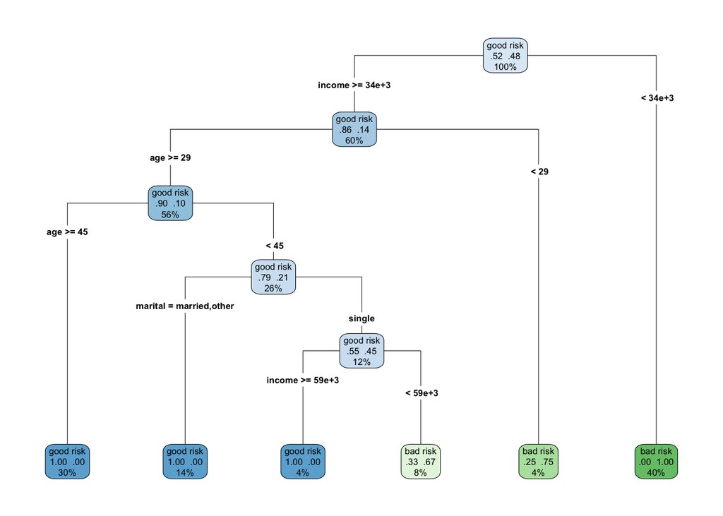

```r
rpart.plot( tree_cart, type = 4, extra = 104 )
```

- C5.0

[figure not shown]

```r
#C5.0 algorithm

set.seed( 5 )

tree_C50 = C5.0( risk ~ mortgage + nr.loans + age + marital + income, data = train_set  )
plot( tree_C50 )
```

- Random Forest

```r
#Random Forest
set.seed( 5 )

random_forest = randomForest( formula = formula, data = train_set, ntree = 10 )
```

Based on the training dataset and the above models predict for the test set. For the prediction, you could use the `predict` function; Similar to the exercises of week 5 in part 1.6.

```r
set.seed(5)
formula = risk ~ mortgage + nr.loans + age + marital + income

#### Prediction with CART (Confusion Matrix / MSE)

tree_cart = rpart( formula = formula, data = train_set, method = "class" )

predict_cart = predict( tree_cart, test_set, type = "class" )

conf.mat( predict_cart, actual_test )
```

```
##            Actual
## Predict     good risk bad risk
##   good risk        25        1
##   bad risk          2       32
```

```r
( mse_cart = mse( predict_cart, actual_test ) )
```

```
## [1] 0.05
```

```r
set.seed(5)
#### Prediction with C5.0 (Confusion Matrix / MSE)

tree_C50 = C5.0( formula = formula, data = train_set, type = "class" )

predict_C50 = predict( tree_C50, test_set, type = "class" )

conf.mat( predict_C50, actual_test )
```

```
##            Actual
## Predict     good risk bad risk
##   good risk        26        4
##   bad risk          1       29
```

```r
( mse_C50 = mse( predict_C50, actual_test ) )
```

```
## [1] 0.08333333
```

```r
set.seed(5)
####Prediction with random forest (Confusion Matrix / MSE)

random_forest = randomForest( formula = formula, data = train_set, ntree = 10 )

predict_random_forest = predict( random_forest, test_set )

conf.mat( predict_random_forest, actual_test )
```

```
##            Actual
## Predict     good risk bad risk
##   good risk        27        2
##   bad risk          0       31
```

```r
( mse_random_forest = mse( actual_test, predict_random_forest ) )
```

```
## [1] 0.03333333
```

- the KNN algorithm

Finding the k-nearest neighbor for the test set, based on the training dataset. Our data contains both categorical and continuous variables. In this case, the min-max normalization are preferred.

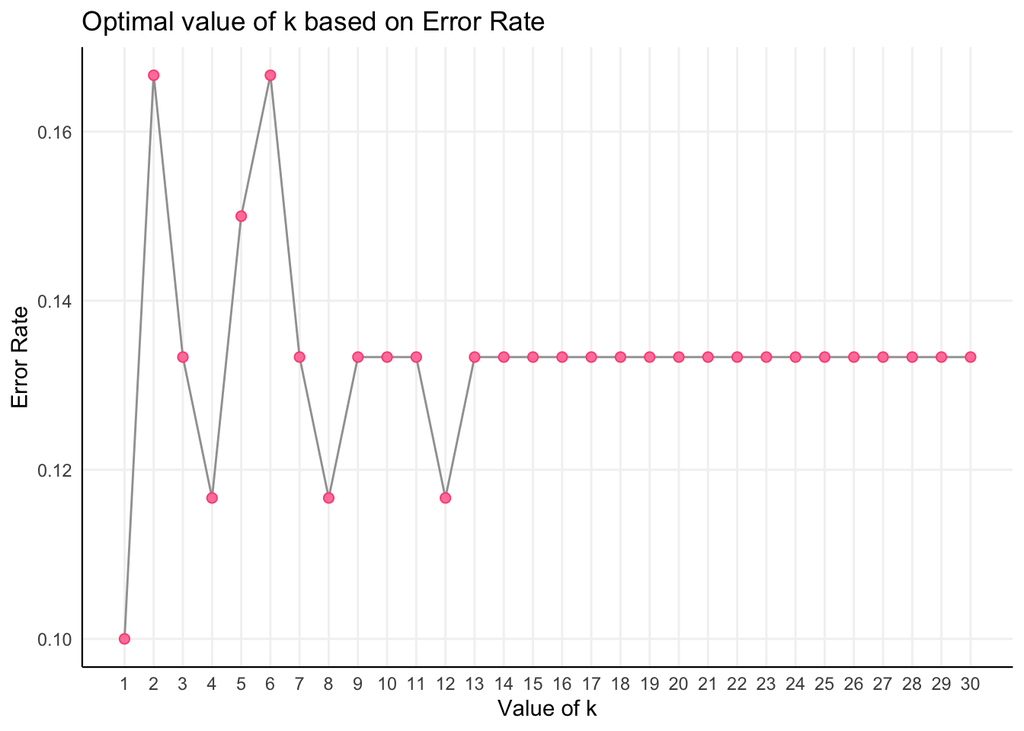

```r
#Finding optimal k
kNN.plot( formula, train = train_set, test = test_set, transform = "minmax",
          k.max = 30, set.seed = 5 )
```

```r
set.seed( 5 )
formula = risk ~ mortgage + nr.loans + age + marital + income
predict_knn = kNN( formula, train = train_set, test = test_set, transform = "minmax", k = 1)
```

```r
#Prediction with kNN

#Confusion matrix kNN
conf.mat(predict_knn, actual_test)
```

```
##            Actual
## Predict     good risk bad risk
##   good risk        23        2
##   bad risk          4       31
```

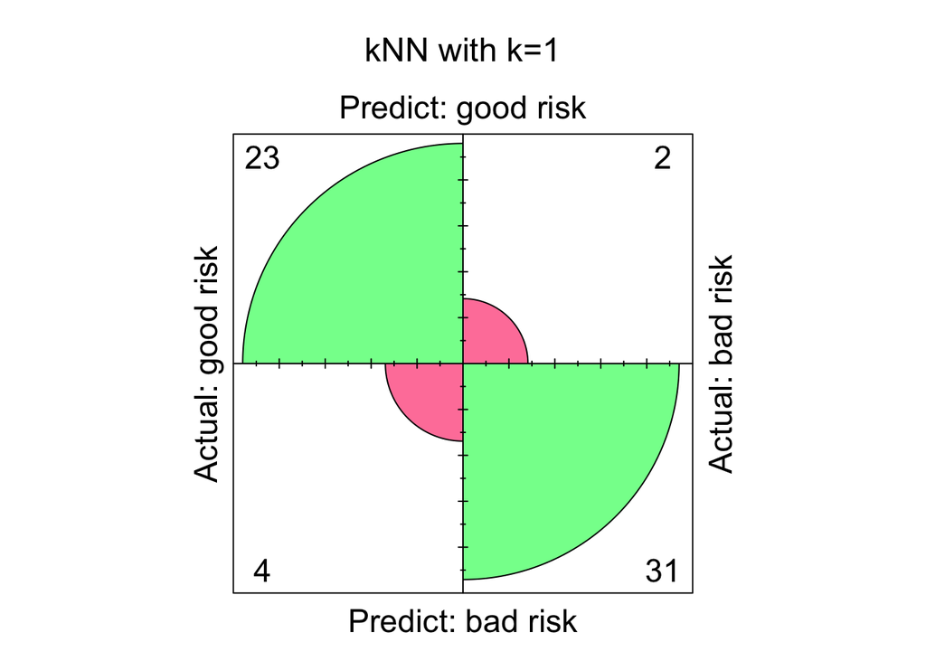

```r
conf.mat.plot(predict_knn, actual_test, main="kNN with k=1")
```

```r
#MSE kNN
(MSE_knn = mse( predict_knn, actual_test))
```

```
## [1] 0.1
```

### Model Evaluation

Based on the results so far, which of the four classification algorithms is more suitable here for the *risk* dataset based on:

- Confusion Matrix,
- MSE,
- ROC curve,
- AUC (Area Under the ROC curve).

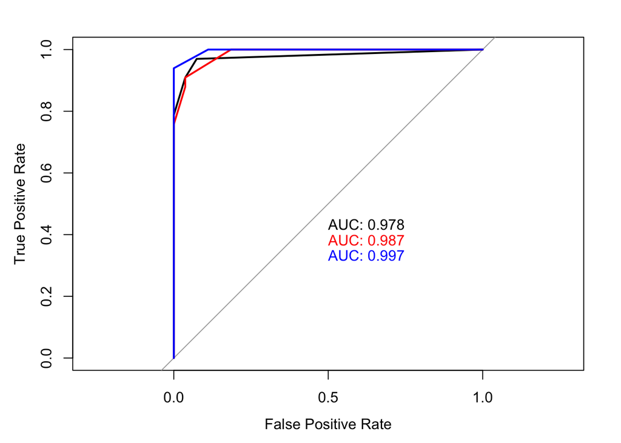

```r
#ROC curve & AUC

prob_cart = predict( tree_cart, test_set, type = "prob" )[ , 1 ]
prob_C50 = predict( tree_C50, test_set, type = "prob" )[ , 1 ]
prob_random_forest = predict( random_forest, test_set, type = "prob" )[ , 1 ]
#prob_knn = kNN( formula, train = train_set, test = test_set, transform = "minmax", k = 1, prob = TRUE )[ , 1 ]


plot.roc( actual_test, prob_cart, legacy.axes = T, col = "black", lwd = 2,
          xlab = "False Positive Rate", ylab = "True Positive Rate", print.auc = T, print.auc.y = 0.45 )
plot.roc( actual_test, prob_C50, legacy.axes = T, add = T, col = "red", print.auc = T, print.auc.y = 0.40 )
plot.roc( actual_test, prob_random_forest, legacy.axes = T, add = T, col = "blue", print.auc = T, print.auc.y = 0.35 )
```

```r
#plot.roc(actual_test, prob_knn, legacy.axes = T, add = T, col = "green", print.auc = T, print.auc.y = 0.30)
```